# Somatic SNV Filtering

July 2017

## Outline

- What factors complicate somatic SNV calling and why is additional filtering necessary?
- CaVEMan filters
- Metric-based approach to filtering false positives
- Other approaches to filtering (panel of normals, ensemble calling)
- Benchmarks for assessing SNV calling and filtering

## Recap: several factors complicate somatic SNV calling

- **Low cellularity** (tumour DNA content)
- **Intra-tumour heterogeneity** in which multiple tumour cell populations (subclones) exist
- **Aneuploidy**
- Unbalanced structural variation (deletions, duplications, etc.)
- Matched **normal contaminated with cancer** DNA
  - adjacent normal tissue may contain residual disease or early tumour-initiating somatic mutations
  - circulating tumour DNA in blood normals
- Sequencing errors
- Alignment artefacts

[Mwenifumbo & Marra, Nat Rev Genet. 2013](http://www.ncbi.nlm.nih.gov/pubmed/23594910)

## Sequencing error

- Base qualities drop off toward ends of reads on Illumina sequencing platform, errors in base calls more likely

**Filter**: *minimum base quality for variant alleles* [CaVEMan `--min-base-qual` parameter]

**Filter**: *no variant alleles found in first 2/3 of a read* [CaVEMan RP filter]

## Low base qualities for variant alleles toward ends of reads

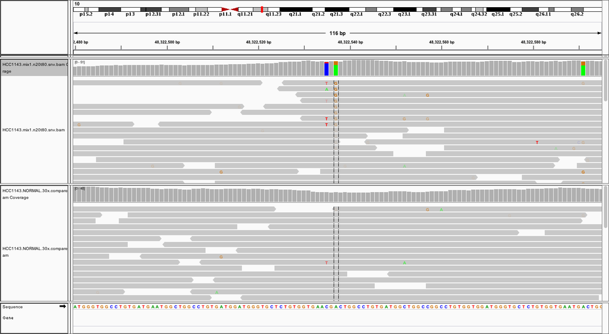

## Technical bias

- Duplicate reads
  - PCR amplification during library construction introduces duplicate reads
  - Bioinformatic tools identify likely PCR duplicates based on aligned start positions of both ends of a read pair

**Post-alignment**: *mark duplicate reads and exclude from SNV calling*

- Strand bias
  - Calls supported mainly by reads aligning to one strand may also be PCR artefacts

**Filter**: *variant alleles in reads aligning in one direction only* [SE filter]

## Strand bias

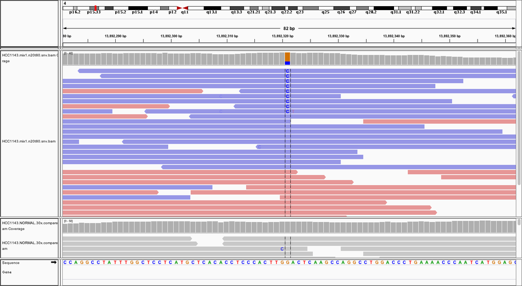

## Technical bias

- GC bias
  - Stretches of low GC content tend to be under-represented leading to uneven coverage across the genome
  - Poor confidence in calls at these low coverage regions as germline SNVs more likely to be mistaken for somatic SNVs due to inadequate sampling in the matched normal

**Filter**: *minimum read depth at variant position particularly in the normal*

**Filter**: *minimum number of reads supporting variant call*

## Alignment issues

Alignment issues are common source of false positive SNV calls

- Missing sequence in the reference genome causes misalignments, usually with mismatches

**Alignment**: *use decoy sequence included in reference genome used by 1000 Genomes project*

**Filter**: *variants supported by reads with many mismatches*

- Assembly in region around variant may differ from the the reference sequence causing incorrect alignments, e.g. indels, rearrangements

**Post-alignment**: *Perform local realignment around indels* [[GATK IndelRealigner](https://gatkforums.broadinstitute.org/gatk/discussion/7156/howto-perform-local-realignment-around-indels)]

**Filter**: *variants within or close to germline indels* [GI filter]

**Filter**: *variant position always toward beginning/end of alignment* [RP filter]

## Missing sequence from reference genome assembly

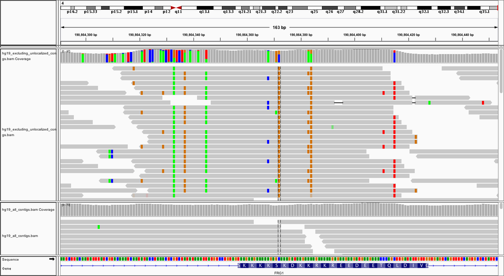

## Problematic alignment around indels

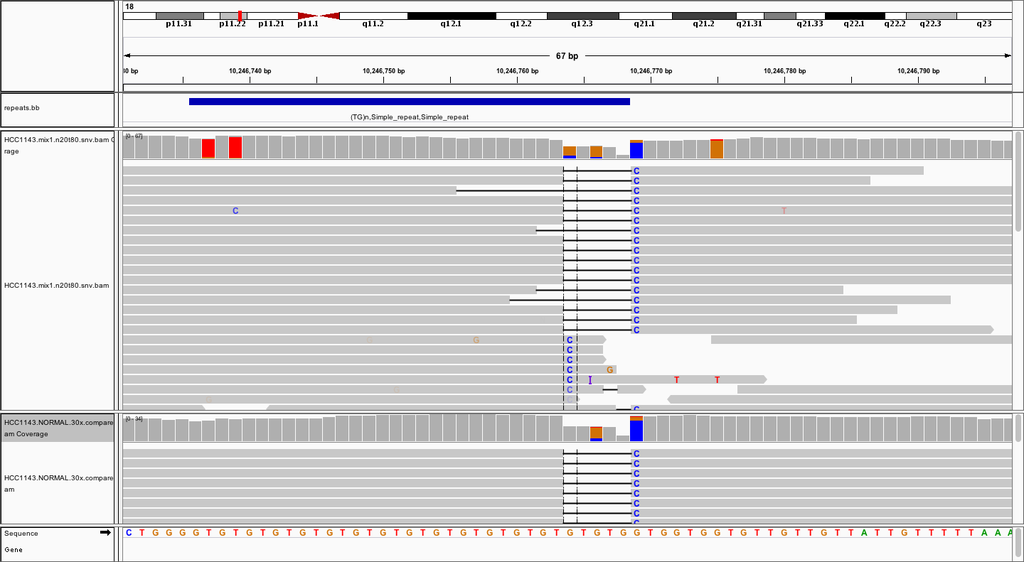

## Alignment issues

- Repetitive regions in the genome cause difficulties for alignment tools
  - Aligners assign a mapping quality of 0 if they cannot uniquely place a read
  - Regions of low mappability are usually out of bounds for short read sequencing

**Filter**: *minimum mapping quality of variant reads* [MQ filter]

**Filter**: *calls from low-complexity and low-mappability regions* [SR, CR filters]

## Low mapping quality

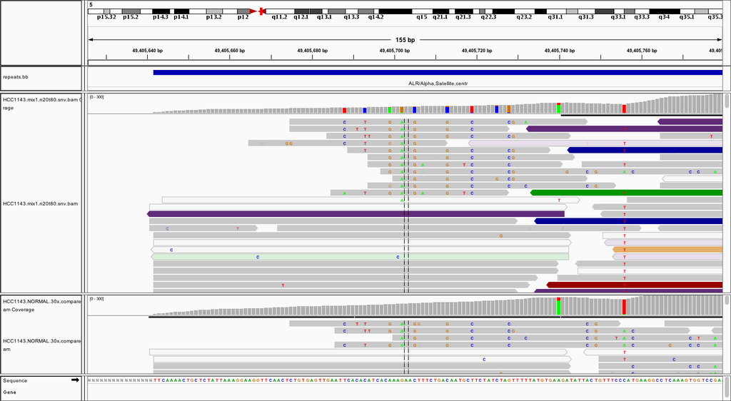

## CaVEMan filters

**HCC1143 dataset:** 138042 of 159001 (**87%**) of initial SNV calls made by CaVEMan are filtered

| Filter | Description | Count |
| --- | --- | --- |
| MQ | Mean mapping quality of the mutant allele reads was &lt; 21 | 43443 |
| DTH | Less than 1/3 mutant alleles were &gt;= 25 base quality | 21973 |
| RP | Coverage was less than 8 and no mutant alleles were found in the first 2/3 of a read | 9541 |
| MNP | Tumour sample mutant allele proportion - normal sample mutant allele proportion &lt; 0.2 | 119779 |
| MN | More than 0.05 of mutant alleles that were &gt;= 15 base quality found in the matched normal | 89613 |
| SE | Coverage is &gt;= 10 on each strand but mutant allele is only present on one strand | 56482 |
| GI | Position falls within a germline indel using the supplied bed file | 5827 |
| SR | Position falls within a simple repeat using the supplied bed file | 34818 |
| CR | Position falls within a centromeric repeat using the supplied bed file | 2126 |
| HSD | Position falls within a high sequencing depth region using the supplied bed file | 5021 |

[output cut: 1 more lines]

## Filtering strategies

**Hard filters**

- Based on summary statistics, or metrics, computed from the sequence reads covering the variant position, e.g. average mapping or base quality scores

**Ensemble calling**

- Consensus call set from majority voting on candidate SNVs called by multiple callers

**Blacklisting**

- Exclude list of problematic genomic positions and/or substitutions, e.g. based on panel of normals

**Machine learning techniques**

- Computers can potentially be trained to recognize characteristics that distinguish true variants from erroneous calls [[GATK Variant Quality Score Recalibration](https://gatkforums.broadinstitute.org/gatk/discussion/39/variant-quality-score-recalibration-vqsr), [mutationSeq](http://compbio.bccrc.ca/software/mutationseq/)]

## Creating, tuning and testing filters

- Benchmark datasets can be used to tune and assess filters
- Ideally need to test filters on separate dataset to that used for training
- Danger of overfitting
- Approach:
  - Plot distribution of true and false positive variants for variety of metrics
  - Choose threshold to best distinguish between TP and FP

*Here we use the ICGC medulloblastoma benchmark dataset to derive filters and the ICGC-TCGA DREAM Challenge sythentic dataset 4 to test these filters.*

## Benchmark datasets

**ICGC benchmarking exercise**

- Medulloblastoma tumour/normal pair sequenced in 6 different centres to combined 300-fold coverage used to establish 'truth'
- 16 ICGC project teams ran their pipelines on data from one centre (40x)

[Alioto et al., Nat Commun. 2015](http://www.ncbi.nlm.nih.gov/pubmed/26647970)

**ICGC-TCGA DREAM Somatic Mutation Calling challenge**

[Ewing et al., Nat Methods 2015](http://www.ncbi.nlm.nih.gov/pubmed/25984700) [[leaderboards](https://www.synapse.org/#!Synapse:syn312572/wiki/58893)]

## Average base quality of variant supporting reads

[interactive chart not shown]

## Average mapping quality of variant reads

[interactive chart not shown]

## Difference in mapping quality between variant and reference reads

[interactive chart not shown]

## Calculating metrics and applying filters

- CalculateSNVMetrics tool available in CRUK-CI gatk-tools package
- [VariantFiltration](https://software.broadinstitute.org/gatk/documentation/tooldocs/org_broadinstitute_gatk_tools_walkers_filters_VariantFiltration.php) tool in the Genome Analysis Toolkit (GATK)

```
# filter set 1 (complements MuTect2's own in-built hard filters)

java -jar GenomeAnalysisTK.jar \
  --analysis_type VariantFiltration \
  --reference_sequence reference.fasta \
  --variant input.vcf \
  --out output.vcf \
  --filterName VariantAlleleCount    --filterExpression "VariantAlleleCount < 3" \
  --filterName VariantCountControl   --filterExpression "VariantAlleleCountControl > 1" \
  --filterName VariantBaseQualMedian --filterExpression "VariantBaseQualMedian < 25.0" \
  --filterName VariantMapQualMedian  --filterExpression "VariantMapQualMedian < 40.0" \
  --filterName MapQualDiffMedian     --filterExpression "MapQualDiffMedian < -5.0 || MapQualDiffMedian > 5.0" \
  --filterName LowMapQual            --filterExpression "LowMapQual > 0.05"
```

## ICGC MB99 benchmark – applying filters

[interactive chart not shown]

## DREAM challenge synthetic 4 dataset – testing filters

[interactive chart not shown]

## DREAM challenge synthetic 4 dataset

SNVs called by MuTect2 (12432 true, 665 false, 3836 not called)

[interactive chart not shown]

## Panel of Normals filter (PoN)

- Artefacts usually cancel out in the tumour normal comparison but depends on adequate sampling
  - Low depth in normal can cause germline variants to appear as somatic
- An approach to detecting likely artefacts is to look for the variant in a panel of unrelated normal samples
  - Filters both polymorphisms and locations prone to aberrant mapping or systematic sequencing artefacts

cgpCaVEManWrapper [[Jones et al., 2016](https://www.ncbi.nlm.nih.gov/pubmed/27930805)]

**CRUK-CI blacklist**

- Based on 50x sequence data for 149 blood normal samples from the UK oesophageal cancer ICGC project
- Variants appearing in at least 5 normals (minimum 3 reads, 5% allele fraction in each sample)

## DREAM challenge synthetic 4 dataset – PoN filter

[interactive chart not shown]

## Combining results from multiple SNV callers

*Can combining the results from multiple callers improve accuracy?*

**Ensemble calling**

- Majority voting on candidate SNVs from multiple callers to produce consensus call set
- ICGC PanCancer project using SNV calls made by at least 2 out of 4 callers (CaVEMan, MuTect2, MuSE, samtools)
- [bcbio](https://bcbio-nextgen.readthedocs.io/en/latest/) cancer variant calling pipeline – also see Brad Chapman's [blog](https://bcbio.wordpress.com/2015/03/05/cancerval)
- SomaticSeq [[Fang et al, 2014](https://www.ncbi.nlm.nih.gov/pubmed/26381235)]

## ICGC MB99 Benchmark – Ensemble call sets

[interactive chart not shown]

## Summary

- SNV calling in cancer genomes is difficult for many reasons
- Using an SNV caller out-of-the-box may give a reasonable set of calls but is likely to result in call sets with higher sensitivity at the expense of precision
- Simple filtering strategies can improve precision but there is a trade-off between sensitivity and accuracy
- The cancer genome sequencing community has been active in establishing benchmark datasets that can be used to assess and improve somatic mutation calling pipelines